# tweet_clean

## Text Cleaning

### Introduction

In this page, I will introduce the methods I used to clean text data, as well as the reasons why I chose to use these methods due to the purpose of transparency. The code that I wrote to clean the data can be found here: https://github.com/anly501/anly-501-project-yeyaxin1103/tree/main/codes/02-data-cleaning

### Data 1: Twitter Search Responses (Tweets)

#### Language Used for Cleaning: Python

#### Data Source: https://github.com/anly501/anly-501-project-yeyaxin1103/tree/main/data/00-raw-data/twitter_api_data

This data was pulled from Twitter using Twitter API for keyword searching. Due to the reason that this project focuses on the fertility rate issue in East Asia, the response Tweets must contain either one or multiple of these following keyword: “China Fertility”, “Korea Fertility”, “Japan Fertility”, “Hong Kong Fertility”, “Mongolia Fertility”, and “Taiwan Fertility”. The data extraction process was repeated twice due to the limitation of tweet amount, and the results of the response tweets will be combined for the text analysis.

```python
### IMPORT PACKAGES
from sklearn.feature_extraction.text import CountVectorizer
import numpy as np
import string
import nltk
# nltk.download('words')
# nltk.download('punkt')
# nltk.download('averaged_perceptron_tagger')
# nltk.download('wordnet')
# nltk.download('stopwords')
# nltk.download([
#     "names",
#     "stopwords",
#     "state_union",
#     "twitter_samples",
#     "movie_reviews",
#     "averaged_perceptron_tagger",
#     "vader_lexicon",
#     "punkt",
#     "omw-1.4"
# ])
import json
import re
```

```python
# read json file as dictionary
with open ("../../data/00-raw-data/twitter_api_data/Tweets_EN.json") as tweetFile:
    tweets1 = json.load(tweetFile)

with open ("../../data/00-raw-data/twitter_api_data/Tweets_EN2.json") as tweetFile:
    tweets2 = json.load(tweetFile)
```

A snapshot of the first Twitter response JSON file:

```python
print('Number of tweets:', len(tweets1))

dict(list(tweets1.items())[:3])
```

```
Number of tweets: 546
```

```
{'Tweet1': {'text': 'RT @VSkirbekk: Gradual convergence in fertility between China and Western countries https://t.co/0Vus39KUxg',
  'id': '1575191634026717184',
  'author_id': '1116548763168858112',
  'created_at': '2022-09-28T18:32:05.000Z'},
 'Tweet2': {'text': "RT @nytimes: South Korea has had the world's lowest total fertility rate for years. The mayor of Seoul said more nannies would encourage co…",
  'id': '1575190110920114178',
  'author_id': '1364997075851599873',
  'created_at': '2022-09-28T18:26:02.000Z'},
 'Tweet3': {'text': "RT @nytimes: South Korea has had the world's lowest total fertility rate for years. The mayor of Seoul said more nannies would encourage co…",
  'id': '1575189759550693377',
  'author_id': '1231317688288468994',
  'created_at': '2022-09-28T18:24:38.000Z'}}
```

A snapshot of the second Twitter response JSON file:

```python
print('Number of tweets:', len(tweets2))

dict(list(tweets2.items())[:3])
```

```
Number of tweets: 229
```

```
{'Tweet1': {'created_at': '2022-10-10T00:48:55.000Z',
  'text': 'This 10/10 marks the 111th #commemoration of #Taiwan #ROC #NationalDay.  Good commemoration to the people and Government of the Island. May #democracy continue to find on this wonderful soil, the fertility necessary for its expansion and serve as an example in the Indo-Pacific.',
  'id': '1579272731853729793',
  'author_id': '257172523',
  'edit_history_tweet_ids': ['1579272731853729793']},
 'Tweet2': {'created_at': '2022-10-09T22:04:45.000Z',
  'text': 'https://t.co/7tBTS1HiFd',
  'id': '1579231416675487745',
  'author_id': '15247533',
  'edit_history_tweet_ids': ['1579231416675487745']},
 'Tweet3': {'created_at': '2022-10-09T21:36:38.000Z',
  'text': '@EdKim45099409 @mr_mogensen It’s a major issue for all Countries except in parts of Africa. But Korea is leading the way with only half the fertility rate of Europe.',
  'id': '1579224343800053760',
  'author_id': '1497037757251825698',
  'edit_history_tweet_ids': ['1579224343800053760']}}
```

#### Cleaning Process

For the tweets returned from searching, I first converted them from JSON to pandas DataFrame and combined two result sets into one.

```python
# Read JSON file to pandas dataframe
import pandas as pd

def json_to_df(json_response):
    text = []
    id = []
    author_id = []
    created_at = []
    for tweet in json_response:
        text.append(json_response[tweet]['text'])
        id.append(json_response[tweet]['id'])
        author_id.append(json_response[tweet]['author_id'])
        created_at.append(json_response[tweet]['created_at'])
    df = pd.DataFrame({'author_id':author_id, 'id':id, 'created_at':created_at, 'text':text, 'clean_text':text})
    return df
```

```python
df1 = json_to_df(tweets1)
df2 = json_to_df(tweets2)

# merge df1 and df2 into one df
df = pd.concat([df1, df2])
```

```python
df.head()
```

|  | author_id | id | created_at | text | clean_text |
| --- | --- | --- | --- | --- | --- |
| 0 | 1116548763168858112 | 1575191634026717184 | 2022-09-28T18:32:05.000Z | RT @VSkirbekk: Gradual convergence in fertilit... | RT @VSkirbekk: Gradual convergence in fertilit... |
| 1 | 1364997075851599873 | 1575190110920114178 | 2022-09-28T18:26:02.000Z | RT @nytimes: South Korea has had the world's l... | RT @nytimes: South Korea has had the world's l... |
| 2 | 1231317688288468994 | 1575189759550693377 | 2022-09-28T18:24:38.000Z | RT @nytimes: South Korea has had the world's l... | RT @nytimes: South Korea has had the world's l... |
| 3 | 780710885186674688 | 1575188100078133248 | 2022-09-28T18:18:03.000Z | RT @nytimes: South Korea has had the world's l... | RT @nytimes: South Korea has had the world's l... |
| 4 | 178464094 | 1575186284808531969 | 2022-09-28T18:10:50.000Z | RT @koryodynasty: Always trust men to come up ... | RT @koryodynasty: Always trust men to come up ... |

```python
def text_cleaner(text):
    text = text.lower()
    # removing hashtags and mentions
    text = re.sub("@[A-Za-z0-9_]+"," ", text)
    text = re.sub("#[A-Za-z0-9_]+"," ", text)
    # removing links
    text = re.sub(r"http\S+", " ", text)
    text = re.sub(r"www.\S+", " ", text)
    # removing punctuations
    text = re.sub('[()!?]', ' ', text)
    text = re.sub('\[.*?\]',' ', text)
    text = re.sub('[0-9]+', ' ', text)
    # removing non-alphanumeric characters
    text = re.sub("[^a-z0-9]"," ", text)
    return text
```

```python
# ------------- Text Cleaning --------------

# Cleaning text
df['clean_text'] = df['clean_text'].apply(lambda x: text_cleaner(x))

# Remove words that have less than 3 characters
df['clean_text'] = df['clean_text'].apply(lambda x: " ".join([w for w in x.split() if len(w)>3]))

df.head()
```

|  | author_id | id | created_at | text | clean_text |
| --- | --- | --- | --- | --- | --- |
| 0 | 1116548763168858112 | 1575191634026717184 | 2022-09-28T18:32:05.000Z | RT @VSkirbekk: Gradual convergence in fertilit... | gradual convergence fertility between china we... |
| 1 | 1364997075851599873 | 1575190110920114178 | 2022-09-28T18:26:02.000Z | RT @nytimes: South Korea has had the world's l... | south korea world lowest total fertility rate ... |
| 2 | 1231317688288468994 | 1575189759550693377 | 2022-09-28T18:24:38.000Z | RT @nytimes: South Korea has had the world's l... | south korea world lowest total fertility rate ... |
| 3 | 780710885186674688 | 1575188100078133248 | 2022-09-28T18:18:03.000Z | RT @nytimes: South Korea has had the world's l... | south korea world lowest total fertility rate ... |
| 4 | 178464094 | 1575186284808531969 | 2022-09-28T18:10:50.000Z | RT @koryodynasty: Always trust men to come up ... | always trust come with policies women this cas... |

```python
# Tokenization
def tokenization(text):
    text = re.split('\W+', text)
    return text

df['tweet_tokenized'] = df['clean_text'].apply(lambda x: tokenization(x.lower()))

df.head()
```

[output not shown]

```python
# remove stopwords
def remove_stopwords(text):
    # remove stopwords
    stopwords = nltk.corpus.stopwords.words('english')
    text = [word for word in text if word not in stopwords]
    return text

df['tweet_nonstop'] = df['tweet_tokenized'].apply(lambda x: remove_stopwords(x))

df.head()
```

[output not shown]

Later on, I performed stemming and lemmatization process on the clean tokenized text for better interpretation and less variety of the words.

```python
# Stemming
ps = nltk.PorterStemmer()

def stemming(text):
    text = [ps.stem(word) for word in text]
    return text

df['tweet_stemmed'] = df['tweet_nonstop'].apply(lambda x: stemming(x))

df.head()
```

[output not shown]

```python
# Lemmatization
wordnet = nltk.WordNetLemmatizer()

def lemmatizer(text):
    text = [wordnet.lemmatize(word) for word in text]
    return text

df['tweet_lemmatized'] = df['tweet_nonstop'].apply(lambda x: lemmatizer(x))

df.head()
```

|  | author_id | id | created_at | text | clean_text | tweet_tokenized | tweet_nonstop | tweet_stemmed | tweet_lemmatized |
| --- | --- | --- | --- | --- | --- | --- | --- | --- | --- |
| 0 | 1116548763168858112 | 1575191634026717184 | 2022-09-28T18:32:05.000Z | RT @VSkirbekk: Gradual convergence in fertilit... | gradual convergence fertility between china we... | [gradual, convergence, fertility, between, chi... | [gradual, convergence, fertility, china, weste... | [gradual, converg, fertil, china, western, cou... | [gradual, convergence, fertility, china, weste... |
| 1 | 1364997075851599873 | 1575190110920114178 | 2022-09-28T18:26:02.000Z | RT @nytimes: South Korea has had the world's l... | south korea world lowest total fertility rate ... | [south, korea, world, lowest, total, fertility... | [south, korea, world, lowest, total, fertility... | [south, korea, world, lowest, total, fertil, r... | [south, korea, world, lowest, total, fertility... |
| 2 | 1231317688288468994 | 1575189759550693377 | 2022-09-28T18:24:38.000Z | RT @nytimes: South Korea has had the world's l... | south korea world lowest total fertility rate ... | [south, korea, world, lowest, total, fertility... | [south, korea, world, lowest, total, fertility... | [south, korea, world, lowest, total, fertil, r... | [south, korea, world, lowest, total, fertility... |
| 3 | 780710885186674688 | 1575188100078133248 | 2022-09-28T18:18:03.000Z | RT @nytimes: South Korea has had the world's l... | south korea world lowest total fertility rate ... | [south, korea, world, lowest, total, fertility... | [south, korea, world, lowest, total, fertility... | [south, korea, world, lowest, total, fertil, r... | [south, korea, world, lowest, total, fertility... |
| 4 | 178464094 | 1575186284808531969 | 2022-09-28T18:10:50.000Z | RT @koryodynasty: Always trust men to come up ... | always trust come with policies women this cas... | [always, trust, come, with, policies, women, t... | [always, trust, come, policies, women, case, i... | [alway, trust, come, polici, women, case, inge... | [always, trust, come, policy, woman, case, ing... |

```python
# Save DataFrame as csv
df.to_csv("../../data/01-modified-data/tweetEN_clean.csv", header=True, index=False)
```

#### CountVectorizer

Convert a collection of text documents to a matrix of token counts

```python
# CountVectorizer
from sklearn.feature_extraction.text import CountVectorizer

clean_tweets = list(set(df['clean_text']))

vectorizer = CountVectorizer()
X = vectorizer.fit_transform(clean_tweets)

# gives the list of all the words in the sample
vectorizer.get_feature_names_out()
```

```
array(['ability', 'able', 'abortion', ..., 'zmianie', 'zoomers', 'zuki'],
      dtype=object)
```

```python
# Make the count vectorizer dataframe and save it as csv
count_vect_df = pd.DataFrame(X.toarray(), columns=vectorizer.get_feature_names_out())
count_vect_df.head(10)

count_vect_df.to_csv("../../data/01-modified-data/tweetEN_CountVectorizer.csv", header=True, index=False)
```

## Text Data Exploration

#### Data Visualization

Generating Wordcloud for all tweets

```python
# Getting all lemmatized clean words in one string
all_clean_words = []

for i in df['tweet_lemmatized']:
    for j in i:
        all_clean_words.append(j)

# remove duplicate values from the list
all_clean_words = list(set(all_clean_words))

clean_words_str = ' '.join(all_clean_words)

# a snapshot of the string of all clean words
clean_words_str[0:600]
```

```
' india similarly university natural mortality injection picture explains zmianie pacific today resulting message america foriegn percentage sweden increasing annual chemical perhaps confucian mayor reduce gang talked swallowed wonder theory also depends overcome biden three none fallen lillie conte…
```

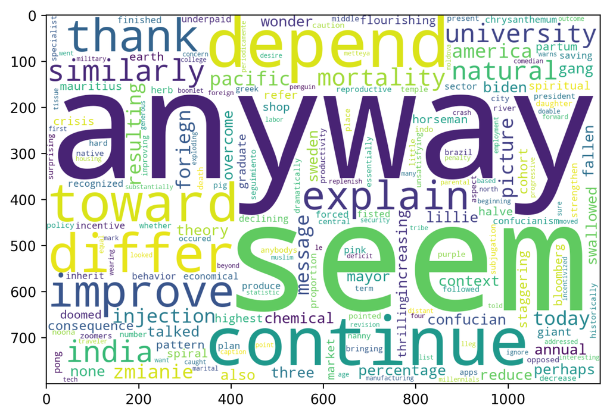

```python
# Plot the wordcloud
from wordcloud import WordCloud
import matplotlib.pyplot as plt

stopwords = nltk.corpus.stopwords.words('english')

wordcloud = WordCloud(width = 1200, height = 800, background_color = 'white',
                      stopwords = stopwords, min_font_size = 10).generate(clean_words_str)

# plot the wordcloud image
plt.figure(figsize = (6,4), facecolor = None, dpi = 300)
plt.imshow(wordcloud)
plt.tight_layout(pad = 0)
plt.savefig("../../501-project-website/images/tweetEN_wordcloud.png")

plt.show()
```